# Saumya Kothari - Computer Vision Project 1 (Part 3, 4, 5)

## Part 3

#### DOMAIN :

Automobile

#### CONTEXT :

A brand research company wants to understand which cars or car manufacturers are popular in a certain area of the city or locality. Company has a team which takes pictures of the cars randomly through the day. Using this the company wants to set up an automation which can classify the make of the car once the picture has been given as an input.

#### TASK :

Help to build the image dataset to be used by the AI team to build an image classifier data. Import and display the images in python against their labels. Comment on the challenges faced during this task. Hint: An image classifier data requires images as data and their tags/labels/class to which they belong.

## Part 4

#### DOMAIN:

Botanical research

#### CONTEXT:

University X is currently undergoing some research involving understanding the characteristics of plant and plant seedlings at various stages of growth. They already have have invested on curating sample images. They require an automation which can create a classifier capable of determining a plant's species from a photo.

#### DATA DESCRIPTION:

The dataset comprises of images from 17 plant species. It can be downloaded from TensorFlow [ Hint: import tflearn.datasets.oxflower17 as oxflower17 ]

#### PROJECT OBJECTIVE:

University’s management require an automation which can create a classifier capable of determining a plant's species from a photo

**Steps and tasks: [ Total Score: 25 points]**

1. Import the data. Analyse the dimensions of the data.
2. Preprocess the data.
3. Data visualisation: • Display the images • Display the labels • Display images vs labels • Apply different filters [ for example: blur, contour, edge detection, emboss, smooth etc.] on the images and display the image.
4. Train tune and test AIML image classifier model using: • Use supervised learning algorithms for training • Use neural networks for training • Use CNN for training • Use various CNN with transferred learning models for training • Compare the results from the above step along with your detailed observations.
5. Create a GUI to import the image “Prediction.jpg” and use the above designed AIML image classification model to predict the class/label of this image.

## Part 5

Explain in depth your strategy to maintain and support the AIML image classifier after it in production

# Solutions

## Part 3

```python
import numpy as np
import pandas as pd
import os
import matplotlib.pyplot as plt
from keras.preprocessing import image
from mpl_toolkits.axes_grid1 import ImageGrid
```

```python
base_path_file_location = os.getcwd()
train_path_add = base_path_file_location + '\\cars_train\\cars_train'
cars_df = pd.read_csv('cars_info.csv')
cars_df.head(20)
```

|  | fname | color | make | class_name |
| --- | --- | --- | --- | --- |
| 0 | 00001.jpg | White | Audi | Audi TTS Coupe 2012 |
| 1 | 00002.jpg | Black | Acura | Acura TL Sedan 2012 |
| 2 | 00003.jpg | Red | Dodge | Dodge Dakota Club Cab 2007 |
| 3 | 00004.jpg | Red | Hyundai | Hyundai Sonata Hybrid Sedan 2012 |
| 4 | 00005.jpg | White | Ford | Ford F-450 Super Duty Crew Cab 2012 |
| 5 | 00006.jpg | Red | Chevrolet | Geo Metro Convertible 1993 |
| 6 | 00007.jpg | Blue | Dodge | Dodge Journey SUV 2012 |
| 7 | 00008.jpg | Red | Dodge | Dodge Charger Sedan 2012 |
| 8 | 00009.jpg | Grey | Mitsubishi | Mitsubishi Lancer Sedan 2012 |
| 9 | 00010.jpg | Grey | Chevrolet | Chevrolet Traverse SUV 2012 |
| 10 | 00011.jpg | White | Buick | Buick Verano Sedan 2012 |
| 11 | 00012.jpg | Grey | Toyota | Toyota Sequoia SUV 2012 |
| 12 | 00013.jpg | White | Hyundai | Hyundai Elantra Sedan 2007 |
| 13 | 00014.jpg | White | Dodge | Dodge Caravan Minivan 1997 |
| 14 | 00015.jpg | Red | Volvo | Volvo C30 Hatchback 2012 |
| 15 | 00016.jpg | Red | Plymouth | Plymouth Neon Coupe 1999 |
| 16 | 00017.jpg | White | Audi | Audi TTS Coupe 2012 |
| 17 | 00018.jpg | White | Chevrolet | Chevrolet Malibu Sedan 2007 |
| 18 | 00019.jpg | Red | Volkswagen | Volkswagen Beetle Hatchback 2012 |
| 19 | 00020.jpg | White | Chevrolet | Chevrolet Corvette Ron Fellows Edition Z06 2007 |

### Import images

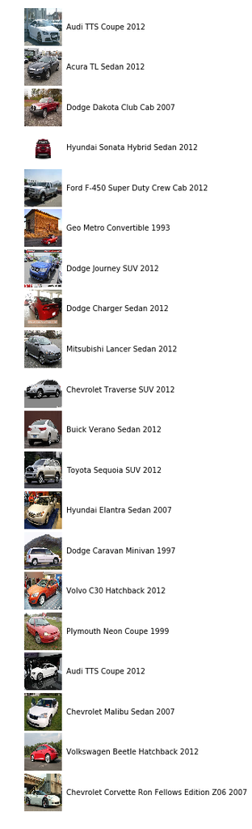

```python
categories = cars_df['class_name'].to_list()
num_of_catogeries = len(categories)

figure = plt.figure(1, figsize=(num_of_catogeries, num_of_catogeries))
grid = ImageGrid(figure, 111, nrows_ncols=(num_of_catogeries, 1), axes_pad=0.05)

def read_img(filepath, size):
    img = image.load_img(os.path.join(base_path_file_location, filepath), target_size=size)
    img = image.img_to_array(img)
    return img

#Displaying images and their corresponding tagged targets

for index, row in cars.iterrows():
    Ax = grid[index]
    img=read_img(train_path_add + "\\" + row["fname"], (224, 224))
    Ax.imshow(img / 255.)
    Ax.axis('off')
    Ax.text(250, 112, row['class_name'], verticalalignment='center')

plt.show();
```

### Comment on the challenges faced during this task

1. There was a LOT of additional efforts that had to be put in from my end: I had to initially find images of different types of cars (Make, Color, class_name), and then take different varieties present. Lots of effort was taken to enter in make and color for every example I entered in.
2. The size of the dataset did not pose a challenge in this case as only limited (20) amount of images were used, but with a larger dataset, memory space and run time issues may arise.

## Part 4

```python
import tflearn
```

[output not shown]

```python
from tflearn.layers.core import input_data, dropout, fully_connected
from tflearn.layers.conv import conv_2d, max_pool_2d
from tflearn.layers.estimator import regression

#Data loading and preprocessing
import tflearn.datasets.oxflower17 as oxflower17
X_train, Y_train = oxflower17.load_data(one_hot = True)
```

#### Import Packages

```python
import numpy as np
import pandas as pd
import os
import tensorflow as tf
import matplotlib.pyplot as plt
import cv2
import keras
from keras.layers import Dense,Conv2D,Dropout,BatchNormalization,Activation,Flatten,MaxPool2D,Input,LeakyReLU
from keras.models import Sequential
from keras.activations import relu
from keras.optimizers import Adam,RMSprop,SGD
from keras.preprocessing.image import ImageDataGenerator
from keras.utils import to_categorical
import pandas as pd
import numpy as np
from keras.applications.vgg16 import VGG16
from sklearn import svm
from keras.preprocessing import image
import xgboost
from sklearn.linear_model import LogisticRegression
from sklearn.metrics import accuracy_score
import os
from sklearn.model_selection import train_test_split
import sklearn.preprocessing as pr
from sklearn.metrics import accuracy_score
from sklearn.svm import SVC
from sklearn.metrics import roc_curve, auc
from mpl_toolkits.axes_grid1 import ImageGrid
from PIL import Image
```

```python
print("X_train -> ", X_train.shape)
print("Y_train -> ", Y_train.shape)
```

```
X_train ->  (1360, 224, 224, 3)
Y_train ->  (1360, 17)
```

#### Data Visualization

```python
dictionary = {0: 'Daffodil', 1: 'Snowdrop', 2: 'Daisy', 3: 'ColtsFoot', 4: 'Dandelion', \
       5: 'Cowslip', 6: 'Buttercup', 7: 'Windflower', 8: 'Pansy', 9:'LilyValley', \
       10: 'Bluebell', 11: 'Crocus', 12: 'Iris', 13: 'Tigerlily', 14:'Tulip', \
       15: 'Fritillary', 16: 'Sunflower'}

class_names = ['Daffodil','Snowdrop','Daisy','ColtsFoot','Dandelion','Cowslip','Buttercup','Windflower',
               'Pansy','LilyValley','Bluebell','Crocus', 'Iris','Tigerlily','Tulip','Fritillary','Sunflower']
```

#### Plotting Images, Labels and Images vs. Labels

```
y = [0. 0. 0. 0. 0. 0. 0. 0. 0. 0. 0. 0. 0. 0. 1. 0. 0.]

y = 14 ; the sample 72 corresponds to a/an Tulip
```

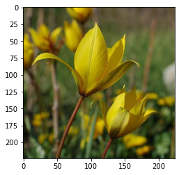

```python
# Plotting the content of a sample

samples = [72,45,879,23,654]

plt.imshow(X_train[samples[0]]);
print('y =',  np.squeeze(Y_train[samples[0]]))
for i in [i for i,x in enumerate(Y_train[samples[0]]) if x == 1]:
    print('')
print('y =',  i, ';', 'the sample', samples[0], 'corresponds to a/an', dictionary[i])
```

```
y = [0. 0. 0. 0. 0. 0. 1. 0. 0. 0. 0. 0. 0. 0. 0. 0. 0.]

y = 6 ; the sample 45 corresponds to a/an Buttercup
```

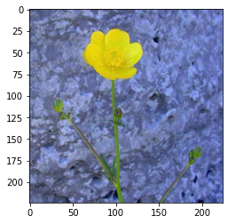

```python
plt.imshow(X_train[samples[1]]);
print('y =',  np.squeeze(Y_train[samples[1]]))
for i in [i for i,x in enumerate(Y_train[samples[1]]) if x == 1]:
    print('')
print('y =',  i, ';', 'the sample', samples[1], 'corresponds to a/an', dictionary[i])
```

```
y = [0. 0. 0. 0. 1. 0. 0. 0. 0. 0. 0. 0. 0. 0. 0. 0. 0.]

y = 4 ; the sample 879 corresponds to a/an Dandelion
```

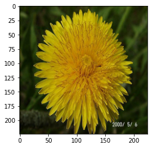

```python
plt.imshow(X_train[samples[2]]);
print('y =',  np.squeeze(Y_train[samples[2]]))
for i in [i for i,x in enumerate(Y_train[samples[2]]) if x == 1]:
    print('')
print('y =',  i, ';', 'the sample', samples[2], 'corresponds to a/an', dictionary[i])
```

```
y = [0. 0. 0. 1. 0. 0. 0. 0. 0. 0. 0. 0. 0. 0. 0. 0. 0.]

y = 3 ; the sample 23 corresponds to a/an ColtsFoot
```

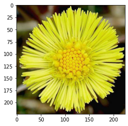

```python
plt.imshow(X_train[samples[3]]);
print('y =',  np.squeeze(Y_train[samples[3]]))
for i in [i for i,x in enumerate(Y_train[samples[3]]) if x == 1]:
    print('')
print('y =',  i, ';', 'the sample', samples[3], 'corresponds to a/an', dictionary[i])
```

```
y = [0. 0. 0. 0. 0. 0. 0. 0. 0. 0. 0. 1. 0. 0. 0. 0. 0.]

y = 11 ; the sample 654 corresponds to a/an Crocus
```

[figure not shown]

```python
plt.imshow(X_train[samples[4]]);
print('y =',  np.squeeze(Y_train[samples[4]]))
for i in [i for i,x in enumerate(Y_train[samples[4]]) if x == 1]:
    print('')
print('y =',  i, ';', 'the sample', samples[4], 'corresponds to a/an', dictionary[i])
```

### Applying Different Filters

[figure not shown]

```python
#cv2.imwrite('flower.jpeg', train_x[samples[4]])

import matplotlib.image as mpimg
import matplotlib.pyplot as plt

# Read Images
image = mpimg.imread('flowers.jpg')

# Output Images
plt.imshow(image)
```

#### Gaussian Blur

[figure not shown]

```python
GblurImg = cv2.GaussianBlur(image, (5, 5), 0)
plt.imshow(GblurImg)
```

#### Blur

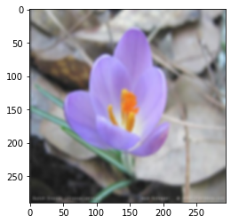

```python
blurImg = cv2.blur(image, (5, 5), 0)
plt.imshow(blurImg)
```

#### Median Blur

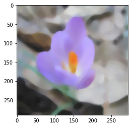

```python
blurred = cv2.medianBlur(image, 15)
plt.imshow(blurred)
```

#### Contour

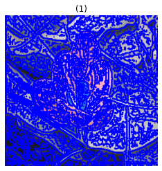

```python
def show_images(images,titles=None, scale=1.3):
    """Display a list of images"""
    n_ims = len(images)
    if titles is None: titles = ['(%d)' % i for i in range(1,n_ims + 1)]
    fig = plt.figure()
    n = 1
    for image,title in zip(images,titles):
        a = fig.add_subplot(1,n_ims,n) # Make subplot
        if image.ndim == 2: # Is image grayscale?
            plt.imshow(image)
        else:
            plt.imshow(cv2.cvtColor(image, cv2.COLOR_RGB2BGR))
        a.set_title(title)
        plt.axis("off")
        n += 1

def display_contours(image, contours, color = (255, 0, 0), thickness = -1, title = None):
    # Contours are drawn on the original image, so let's make a copy first
    imShow = image.copy()
    for i in range(0, len(contours)):
        cv2.drawContours(imShow, contours, i, color, thickness)
    show_images([imShow], scale=0.7, titles=title)

# this is a good threshold for Canny edge finder, but it does not always work. We will see how to deal with it furhter on.
thresh = 4
# Searcing for the eye
# Let's see how this works setp-by-step
# convert to a one channel image
gray = cv2.cvtColor(image, cv2.COLOR_BGR2GRAY)

# Canny edge finder
edges = np.array([])
edges = cv2.Canny(gray, thresh, thresh * 3, edges)

# Find contours
# second output is hierarchy - we are not interested in it.
contours, _ = cv2.findContours(edges, cv2.RETR_EXTERNAL, cv2.CHAIN_APPROX_SIMPLE)

# Let's see what we've got:
display_contours(image, contours, thickness=2)
#print "{:d} points".format(len(np.vstack(np.array(contours))))
```

#### Edge Detection

[figure not shown]

```python
edges = cv2.Canny(image,100,200)
plt.imshow(edges,cmap = 'gray')
```

### Train tune and test AIML image classifier model using:

### Supervised Learning

```python
import numpy as np
y = np.argmax(Y_train, axis=1)

x_svm,x_test_svm,y_svm,y_test_svm =  train_test_split(X_train,y ,test_size=0.2,random_state=10)
x_array_svm = np.array(x_svm)
x_test_arr_svm = np.array(x_test_svm)
y_train_cat = to_categorical(y)


flat_arr_size = len(x_array_svm[0])*len(x_array_svm[0][0])*len(x_array_svm[0][0][0])
x_arr_flat_svm = x_array_svm.reshape(len(x_array_svm),flat_arr_size)
x_test_arr_flat_svm = x_test_arr_svm.reshape(len(x_test_arr_svm),flat_arr_size)
```

```python
# define support vector classifier
svm = SVC(kernel='linear', probability=True, random_state=10)

# fit model
svm.fit(x_arr_flat_svm, y_svm)
```

```
SVC(kernel='linear', probability=True, random_state=10)
```

```python
# generate predictions
y_pred = svm.predict(x_test_arr_flat_svm)

# calculate accuracy
accuracy = accuracy_score(y_test_svm, y_pred)
print('Model accuracy is: ', accuracy)
```

```
Model accuracy is:  0.4889705882352941
```

### Neural Networks

```python
modelNN2 = tf.keras.models.Sequential([
    tf.keras.layers.InputLayer(input_shape=(224,224,3)),
    tf.keras.layers.Flatten(),
    tf.keras.layers.Dense(64, activation='relu'),
    tf.keras.layers.BatchNormalization(),
    tf.keras.layers.Dense(128, activation='relu'),
    tf.keras.layers.Dropout(0.2),
    tf.keras.layers.BatchNormalization(),
    tf.keras.layers.Dense(17, activation='softmax')])

modelNN2.compile(optimizer='adam', loss='categorical_crossentropy', metrics=['accuracy'])
modelNN2.summary()

checkpoint = tf.keras.callbacks.ModelCheckpoint('flower_classifierNN.h5', #where to save the model
                                                    save_best_only=True,
                                                    monitor='val_acc',
                                                    mode='max',
                                                    verbose = 1)
history=modelNN2.fit(X_train,
                     Y_train,
                     batch_size=64,
                     epochs=60,
                     verbose=1,
                     validation_split=0.2,
                     shuffle=True,
                     callbacks = [checkpoint])
```

```
Model: "sequential"
_________________________________________________________________
Layer (type)                 Output Shape              Param #
=================================================================
flatten (Flatten)            (None, 150528)            0
_________________________________________________________________
dense (Dense)                (None, 64)                9633856
_________________________________________________________________
batch_normalization (BatchNo (None, 64)                256
_________________________________________________________________
dense_1 (Dense)              (None, 128)               8320
_________________________________________________________________
dropout (Dropout)            (None, 128)               0
_________________________________________________________________
batch_normalization_1 (Batch (None, 128)               512
_________________________________________________________________
dense_2 (Dense)              (None, 17)                2193
=================================================================
Total params: 9,645,137
Trainable params: 9,644,753
Non-trainable params: 384
_________________________________________________________________
Train on 1088 samples, validate on 272 samples
```

```
Epoch 00001: val_acc improved from -inf to 0.08088, saving model to flower_classifierNN.h5
Epoch 00002: val_acc improved from 0.08088 to 0.10294, saving model to flower_classifierNN.h5
Epoch 00003: val_acc improved from 0.10294 to 0.19118, saving model to flower_classifierNN.h5
Epoch 00004: val_acc improved from 0.19118 to 0.23897, saving model to flower_classifierNN.h5
Epoch 00005: val_acc improved from 0.23897 to 0.29779, saving model to flower_classifierNN.h5
Epoch 00006: val_acc did not improve from 0.29779
Epoch 00007: val_acc improved from 0.29779 to 0.30882, saving model to flower_classifierNN.h5
Epoch 00008: val_acc improved from 0.30882 to 0.33456, saving model to flower_classifierNN.h5
Epoch 00009: val_acc did not improve from 0.33456
Epoch 00010: val_acc did not improve from 0.33456
Epoch 00011: val_acc did not improve from 0.33456
Epoch 00012: val_acc did not improve from 0.33456
Epoch 00013: val_acc did not improve from 0.33456
Epoch 00014: val_acc improved from 0.33456 to 0.41544, saving model to flower_classifierNN.h5
Epoch 00015: val_acc did not improve from 0.41544
Epoch 00016: val_acc did not improve from 0.41544
Epoch 00017: val_acc did not improve from 0.41544
Epoch 00018: val_acc did not improve from 0.41544
Epoch 00019: val_acc did not improve from 0.41544
Epoch 00020: val_acc improved from 0.41544 to 0.43015, saving model to flower_classifierNN.h5
Epoch 00021: val_acc did not improve from 0.43015
Epoch 00022: val_acc did not improve from 0.43015
Epoch 00023: val_acc did not improve from 0.43015
Epoch 00024: val_acc did not improve from 0.43015
Epoch 00025: val_acc did not improve from 0.43015
Epoch 00026: val_acc did not improve from 0.43015
Epoch 00027: val_acc did not improve from 0.43015
Epoch 00028: val_acc did not improve from 0.43015
Epoch 00029: val_acc did not improve from 0.43015
Epoch 00030: val_acc did not improve from 0.43015
Epoch 00031: val_acc did not improve from 0.43015
Epoch 00032: val_acc did not improve from 0.43015
Epoch 00033: val_acc did not improve from 0.43015
Epoch 00034: val_acc did not improve from 0.43015
Epoch 00035: val_acc did not improve from 0.43015
Epoch 00036: val_acc did not improve from 0.43015
Epoch 00037: val_acc did not improve from 0.43015
Epoch 00038: val_acc did not improve from 0.43015
Epoch 00039: val_acc did not improve from 0.43015
Epoch 00040: val_acc did not improve from 0.43015
Epoch 00041: val_acc did not improve from 0.43015
Epoch 00042: val_acc did not improve from 0.43015
Epoch 00043: val_acc did not improve from 0.43015
Epoch 00044: val_acc did not improve from 0.43015
Epoch 00045: val_acc did not improve from 0.43015
Epoch 00046: val_acc did not improve from 0.43015
Epoch 00047: val_acc did not improve from 0.43015
Epoch 00048: val_acc did not improve from 0.43015
Epoch 00049: val_acc did not improve from 0.43015
Epoch 00050: val_acc did not improve from 0.43015
Epoch 00051: val_acc did not improve from 0.43015
Epoch 00052: val_acc did not improve from 0.43015
Epoch 00053: val_acc did not improve from 0.43015
Epoch 00054: val_acc did not improve from 0.43015
Epoch 00055: val_acc did not improve from 0.43015
Epoch 00056: val_acc did not improve from 0.43015
Epoch 00057: val_acc did not improve from 0.43015
Epoch 00058: val_acc did not improve from 0.43015
Epoch 00059: val_acc did not improve from 0.43015
Epoch 00060: val_acc did not improve from 0.43015
```

### CNN

```python
#CNN
modelCNN2 = tf.keras.models.Sequential()

# Input layer
# Can be omitted, you can specify the input_shape in other layers
modelCNN2.add(tf.keras.layers.InputLayer(input_shape=(224,224,3,)))

# Here we add a 2D Convolution layer
# Check https://keras.io/api/layers/convolution_layers/convolution2d/ for more info
modelCNN2.add(tf.keras.layers.Conv2D(64, kernel_size=(3,3), activation='relu'))

# Max Pool layer
# It downsmaples the input representetion within the pool_size size
modelCNN2.add(tf.keras.layers.MaxPool2D(pool_size = (2,2)))

# Normalization layer
# The layer normalizes its output using the mean and standard deviation of the current batch of inputs.
modelCNN2.add(tf.keras.layers.BatchNormalization())

# 2D Convolution layer
modelCNN2.add(tf.keras.layers.Conv2D(64, kernel_size=(3,3), strides = (1,1), activation='relu'))

# Max Pool layer
modelCNN2.add(tf.keras.layers.MaxPool2D(pool_size = (2,2)))

# Normalization layer
modelCNN2.add(tf.keras.layers.BatchNormalization())

# 2D Convolution layer
modelCNN2.add(tf.keras.layers.Conv2D(128, kernel_size=(3,3), strides = (1,1), activation='relu'))

# Max Pool layer
modelCNN2.add(tf.keras.layers.MaxPool2D(pool_size = (2,2)))

# Normalization layer
modelCNN2.add(tf.keras.layers.BatchNormalization())

# 2D Convolution layer
modelCNN2.add(tf.keras.layers.Conv2D(128, kernel_size=(3,3), strides = (1,1), activation='relu'))

# Max Pool layer
modelCNN2.add(tf.keras.layers.MaxPool2D(pool_size = (2,2)))

# Global Max Pool layer
modelCNN2.add(tf.keras.layers.GlobalMaxPool2D())

# Dense Layers after flattening the data
modelCNN2.add(tf.keras.layers.Flatten())

modelCNN2.add(tf.keras.layers.Dense(128, activation='relu'))

# Dropout
# is used to nullify the outputs that are very close to zero and thus can cause overfitting.
modelCNN2.add(tf.keras.layers.Dropout(0.2))
modelCNN2.add(tf.keras.layers.Dense(64, activation='relu'))

# Normalization layer
modelCNN2.add(tf.keras.layers.BatchNormalization())

#Add Output Layer
modelCNN2.add(tf.keras.layers.Dense(17, activation='softmax'))

modelCNN2.compile(optimizer='adam', loss='categorical_crossentropy', metrics=['accuracy'])
modelCNN2.summary()

checkpoint = tf.keras.callbacks.ModelCheckpoint('flower_classifierCNN.h5', #where to save the model
                                                    save_best_only=True,
                                                    monitor='val_acc',
                                                    mode='max',
                                                    verbose = 1)
history=modelCNN2.fit(X_train,
                      Y_train,
                      batch_size=64,
                      epochs=10,
                      verbose=1,
                      validation_split=0.2,
                      shuffle=True,
                      callbacks = [checkpoint])
```

```
Model: "sequential_1"
_________________________________________________________________
Layer (type)                 Output Shape              Param #
=================================================================
conv2d (Conv2D)              (None, 222, 222, 64)      1792
_________________________________________________________________
max_pooling2d (MaxPooling2D) (None, 111, 111, 64)      0
_________________________________________________________________
batch_normalization_2 (Batch (None, 111, 111, 64)      256
_________________________________________________________________
conv2d_1 (Conv2D)            (None, 109, 109, 64)      36928
_________________________________________________________________
max_pooling2d_1 (MaxPooling2 (None, 54, 54, 64)        0
_________________________________________________________________
batch_normalization_3 (Batch (None, 54, 54, 64)        256
_________________________________________________________________
conv2d_2 (Conv2D)            (None, 52, 52, 128)       73856
_________________________________________________________________
max_pooling2d_2 (MaxPooling2 (None, 26, 26, 128)       0
_________________________________________________________________
batch_normalization_4 (Batch (None, 26, 26, 128)       512
_________________________________________________________________
conv2d_3 (Conv2D)            (None, 24, 24, 128)       147584
_________________________________________________________________
max_pooling2d_3 (MaxPooling2 (None, 12, 12, 128)       0
_________________________________________________________________
global_max_pooling2d (Global (None, 128)               0
_________________________________________________________________
flatten_1 (Flatten)          (None, 128)               0
_________________________________________________________________
dense_3 (Dense)              (None, 128)               16512
_________________________________________________________________
dropout_1 (Dropout)          (None, 128)               0
_________________________________________________________________
dense_4 (Dense)              (None, 64)                8256
_________________________________________________________________
batch_normalization_5 (Batch (None, 64)                256
_________________________________________________________________
dense_5 (Dense)              (None, 17)                1105
=================================================================
Total params: 287,313
Trainable params: 286,673
Non-trainable params: 640
_________________________________________________________________
Train on 1088 samples, validate on 272 samples
Epoch 00001: val_acc improved from -inf to 0.06618, saving model to flower_classifierCNN.h5
Epoch 00002: val_acc did not improve from 0.06618
Epoch 00003: val_acc improved from 0.06618 to 0.12500, saving model to flower_classifierCNN.h5
Epoch 00004: val_acc did not improve from 0.12500
Epoch 00005: val_acc did not improve from 0.12500
Epoch 00006: val_acc did not improve from 0.12500
Epoch 00007: val_acc did not improve from 0.12500
Epoch 00008: val_acc did not improve from 0.12500
Epoch 00009: val_acc did not improve from 0.12500
Epoch 00010: val_acc did not improve from 0.12500
```

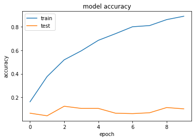

```python
#summarize history for accuracy
plt.plot(history.history['acc'])
plt.plot(history.history['val_acc'])
plt.title('model accuracy')
plt.ylabel('accuracy')
plt.xlabel('epoch')
plt.legend(['train','test'],loc='upper left')
plt.show()
```

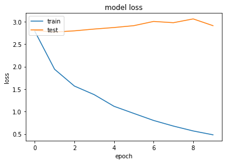

```python
# summarize history for loss
plt.plot(history.history['loss'])
plt.plot(history.history['val_loss'])
plt.title('model loss')
plt.ylabel('loss')
plt.xlabel('epoch')
plt.legend(['train','test'],loc='upper left')
plt.show()
```

#### Use various CNN with transferred learning models for training

```python
base = tf.keras.applications.VGG16(include_top=False, weights='imagenet', input_shape=(224,224,3))
base.trainable = False
model = tf.keras.Sequential([base,
                             tf.keras.layers.GlobalAveragePooling2D(),
                             tf.keras.layers.Dense(128,name="dense100",activation="relu"),
                             tf.keras.layers.Dropout(0.3),
                             tf.keras.layers.Dense(17,activation="softmax")])
base.trainable = True
model.compile(optimizer='adam', loss='categorical_crossentropy', metrics=['accuracy'])
model.summary()
checkpoint = tf.keras.callbacks.ModelCheckpoint('flower_classifierTransferedLearning.h5', #where to save the model
                                                    save_best_only=True,
                                                    monitor='val_acc',
                                                    mode='max',
                                                    verbose = 1)
history=model.fit(X_train,
                  Y_train,
                  batch_size=64,
                  epochs=10,
                  verbose=1,
                  validation_split=0.2,
                  shuffle=True,
                  callbacks = [checkpoint])
```

```
Model: "sequential"
_________________________________________________________________
Layer (type)                 Output Shape              Param #
=================================================================
vgg16 (Functional)           (None, 7, 7, 512)         14714688
_________________________________________________________________
global_average_pooling2d (Gl (None, 512)               0
_________________________________________________________________
dense100 (Dense)             (None, 128)               65664
_________________________________________________________________
dropout (Dropout)            (None, 128)               0
_________________________________________________________________
dense (Dense)                (None, 17)                2193
=================================================================
Total params: 14,782,545
Trainable params: 14,782,545
Non-trainable params: 0
_________________________________________________________________
Train on 1088 samples, validate on 272 samples
C:\ProgramData\Anaconda3\lib\site-packages	ensorflow\python\keras\engine	raining.py:2325: UserWarning: `Model.state_updates` will be removed in a future version. This property should not be used in TensorFlow 2.0, as `updates` are applied automatically.
  warnings.warn('`Model.state_updates` will be removed in a future version. '
Epoch 00001: val_acc improved from -inf to 0.04412, saving model to flower_classifierTransferedLearning.h5
Epoch 00002: val_acc improved from 0.04412 to 0.05147, saving model to flower_classifierTransferedLearning.h5
Epoch 00003: val_acc did not improve from 0.05147
Epoch 00004: val_acc did not improve from 0.05147
Epoch 00005: val_acc did not improve from 0.05147
Epoch 00006: val_acc did not improve from 0.05147
Epoch 00007: val_acc did not improve from 0.05147
Epoch 00008: val_acc did not improve from 0.05147
Epoch 00009: val_acc improved from 0.05147 to 0.07721, saving model to flower_classifierTransferedLearning.h5
Epoch 00010: val_acc improved from 0.07721 to 0.10662, saving model to flower_classifierTransferedLearning.h5
```

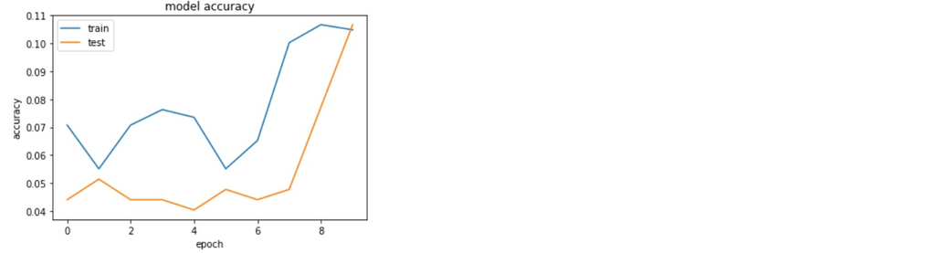

```python
#summarize history for accuracy
plt.plot(history.history['acc'])
plt.plot(history.history['val_acc'])
plt.title('model accuracy')
plt.ylabel('accuracy')
plt.xlabel('epoch')
plt.legend(['train','test'],loc='upper left')
plt.show()
```

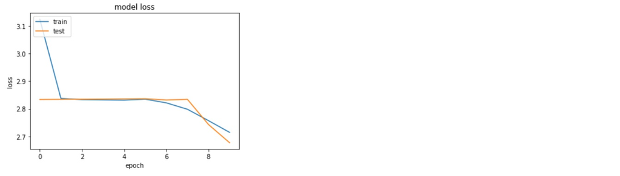

```python
# summarize history for loss
plt.plot(history.history['loss'])
plt.plot(history.history['val_loss'])
plt.title('model loss')
plt.ylabel('loss')
plt.xlabel('epoch')
plt.legend(['train','test'],loc='upper left')
plt.show()
```

## GUI

```python
import tkinter as tk
from tkinter import ttk
import re

win = tk.Tk()
win.title('CLASSIFIER - GUI')

name = ttk.Label(win, text="Step 1: File Name")
name.grid(row = 0, column = 0, sticky = tk.W)

name_var = tk.StringVar()
name_entrybox = ttk.Entry(win, width=16, textvariable = name_var)
name_entrybox.grid(row = 0, column = 1)

def Import_Data():
    global img_array
    df_name = name_var.get()
    img = keras.preprocessing.image.load_img(df_name, target_size=(256, 256))
    img_array = keras.preprocessing.image.img_to_array(img)
    img_array = tf.expand_dims(img_array, 0)

    confirm = "Data Imported Successfully"
    confirm_entrybox = ttk.Entry(win, width=50)
    confirm_entrybox.grid(row = 0, column = 3)
    confirm_entrybox.insert(1, str(confirm))

import_data_button = ttk.Button(win, text = 'Import Data', command= Import_Data)
import_data_button.grid(row = 0, column = 2)

#------------------------------------------------------------------------------------------------------------

target = ttk.Label(win, text="Step 2: Image Classifier")
target.grid(row = 1, column = 0, sticky = tk.W)


def Predict():
    global img_array
    from tensorflow.keras.models import load_model
    model_cnn_loaded = load_model('flower_classifierCNN.h5')
    predictions = model.predict(img_array)
    score = tf.nn.softmax(predictions[0])

    confirm = "This is a image of " + class_names[np.argmax(score)]
    confirm_entrybox = ttk.Entry(win, width=50)
    confirm_entrybox.grid(row = 1, column = 2)
    confirm_entrybox.insert(1, str(confirm))

import_target_column_button = ttk.Button(win, text = 'Predict', command= Predict)
import_target_column_button.grid(row = 1, column = 1)

win.mainloop()

#GUI Opens in new window
```

[figure not shown]

## Part 5

#### Question:

Explain in depth your strategy to maintain and support the AIML image classifier after it in production.

#### Answer:

One major probelm that we face is mantaining the good predictivity after running the model and its production, although it may have a very good accuracy score on its training, validation and test datasets. We can solve this problem by the following:

- We can add a low percentage of negative test data as part of model results. This method of negative testing ensures that the model handles the unwanted input the way it should be handled (wihtout giving a lot of importance to it). A model which is well-trained and has a well-understanding of the data at hand will produce a good and high accuracy for positive data and for negative data, would show a low score for negative data. When there is high success rate from a negative dataset it clearly indicates that some changes need to be made.
- Another popularly used algorithmic trend is that an autoencoder model can be utilised while training the model at hand. This autoencoder uses a special anamoly detection technique which would pass the recent model input data and get a value called 'reconstruction error value (REV)'. A high REV indicates an input differs from original training data. Based on business objective, from recent model results, get the accuracy score on positive data, and negative data, and get reconstruction error value from the AE model. When the model produced with high accuracy score and high negative test accuracy, get the reconstruction error value from the AE model with recent data. If the REV is low, the data is not changed much. This would indicate retraining the model with newly obtained data.
- Retrain the Manually and Continuosly model with new data. In this case, we would need too train the updated data again and again on our same model. This will firstly ensure that the model can readily adapt to new data. However, we need to keep in mind that learning done does not take a toll on the memory space on the desktop which would be running the data and also make sure that the time gap between training and testing is significant to ensure that dynamic learning is taking place.

Lastly, it is important and crucial to know that these AI & ML models do not learn on their own but there needs to be constant learning which is reinforced at periodic intervals which are termed as procative (identifies outliers in testing data) and reactive (identify what led to teh error in output in test data and how to rectify it) model mainteanace

# --------------------------------END OF PROJECT--------------------------------------